Given a sample covariance matrix $\mathbf{S} = \mathbf{X}^T\mathbf{X}$, with $\mathbf{X}$ having dimension $n\times p$, eigen decomposition is performed such that

$$\mathbf{S} = \mathbf{Q}\boldsymbol{\Lambda}\mathbf{Q}^T$$

where $\mathbf{Q} = (\mathbf{q}_1,\mathbf{q}_2,...,\mathbf{q}_n)$ is the matrix of eigenvectors.

Further, for the i$^{th}$ case the j$^{th}$ principal component can be obtained by

$$y_{i j}=\mathbf{x}_{i}^{\top} \mathbf{q}_{j}$$

where $i=1,2,...,n$ and $j=1,2,...,p$.

```r
set.seed(1337)
```

```r
# convert vector to matrix
vec2mat = function(vec, dim) {
    return(matrix(unlist(vec), ncol=dim, byrow=T)[,dim:1])
}
```

Firstly, we fetch the data and extract the observations related to our favorite number 2.

```r
# read data
dat = read.table('HA_2_zip.train')
dat_two <- dat[which(dat[,1] == 2), 2:257]
```

Then, we plotted the first 24 observations of our number.

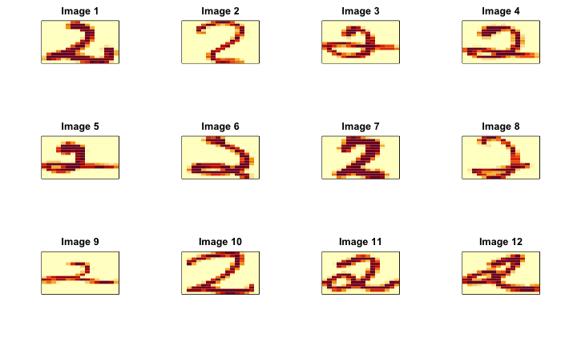

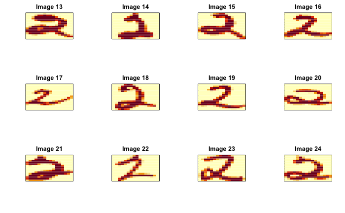

```r
# plot first 24 digits
par(mfrow = c(3, 4))
no = 1
for (n in 1:2) {
    for (i in 1:12) {
        img_i = vec2mat(dat_two[no, 256:1], dim=16)
        image(
            t(img_i), xaxt='n', yaxt='n',
            xlab='', ylab='', main=paste("Image", no)
        )
        no = no + 1
    }
}
```

Consequently, we computed the principal components and plotted the four first and last, respectively, as 16x16 pixel images.

```r
# convert data with digit 2 to matrix
dat_two_mat = matrix(
    unlist(dat_two),
    nrow=dim(dat_two)[1],
    ncol=dim(dat_two)[2]
)

# compute PC's and eigenvectors
S_two = t(dat_two_mat) %*% dat_two_mat
eigen_el = eigen(S_two)
Q_two = eigen_el$vectors
eigen_val = eigen_el$values
pc_two = dat_two_mat %*% Q_two
```

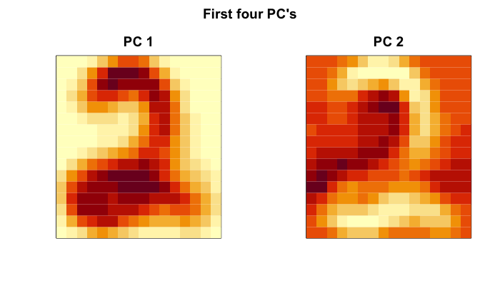

```r
# first 4 PC's
par(mfrow=c(1, 2), oma=c(0, 0, 2, 0))

for (i in 1:4) {
    if (i == 3) {
        par(mfrow=c(1, 2))
    }
    pc = Q_two[, i]
    img = vec2mat(pc[256:1], dim=16)
    image(t(img), xaxt='n', yaxt='n', xlab='', ylab='', main=paste("PC", i))
    if (i == 2) {
        title("First four PC's", outer=T)
    }
}
```

[figure not shown]

```r
NA
```

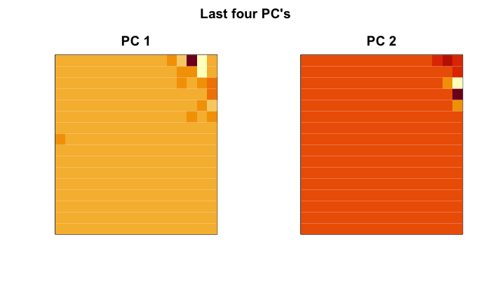

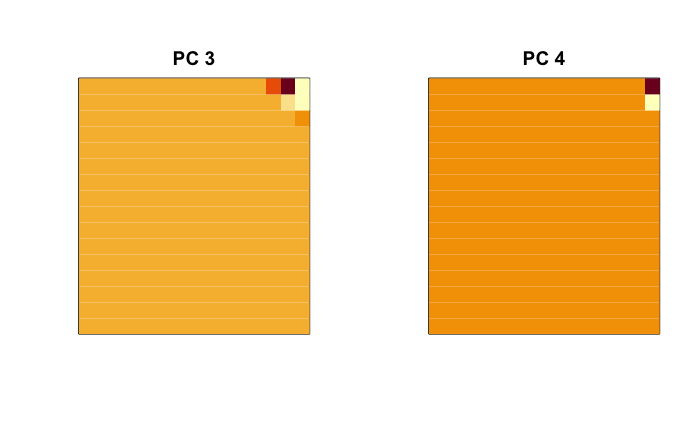

```r
# last 4 PC's
par(mfrow=c(1, 2), oma=c(0, 0, 2, 0))
for (i in 1:4) {
    if (i == 3) {
        par(mfrow=c(1, 2))
    }
    pc = Q_two[, (dim(dat_two_mat)[2] - 4) + i]
    img = vec2mat(pc[256:1], dim=16)
    image(t(img), xaxt='n', yaxt='n', xlab='', ylab='', main=paste("PC", i))
    if (i == 2) {
        title("Last four PC's", outer=T)
    }
}
```

By the principal components previously computed, a randomly selected image was selected and then reconstructed by different number of principal components. Alongside the image reconstruction, the mean-squared error (MSE) was calculated.

```r
set.seed(1337)
par(mfrow=c(2, 3), oma=c(0, 0, 2, 0))
n = c(30, 60, 100, 150, 200)
rnd_idx = sample(1:dim(dat_two_mat)[1], 1)
real_vec = dat_two_mat[rnd_idx, 256:1]
real_img = vec2mat(real_vec, dim=16)
mse = vector()
j = 1
for (i in n) {
    q = Q_two[, 1:i]
    pc = real_vec %*% q
    est_vec = pc %*% t(q)
    img = vec2mat(est_vec, dim=16)
    image(t(img), xaxt='n', yaxt='n', xlab='', ylab='', main=paste(i, "PC's"))

    mse[j] = round(sum((real_vec - est_vec)^2) / length(real_vec), 4)
    j = j + 1
}
image(t(real_img), xaxt='n', yaxt='n', xlab='', ylab='', main="Original Image")
title(paste("Approximation of Image", rnd_idx), outer=T)
```

[output not shown]

```r
mse_df = data.frame(
    n_PC = c(n),
    MSE = c(mse)
)
print(mse_df)
```

[output not shown]

Related to the image reconstruction, the number of principal components needed to explain 85% of the variance was determined and also visualized by a bar plot. It was concluded that we need 21 principal components to explain 85% of the variance.

```r
tot_var = sum(eigen_val)
var_exp = cumsum(eigen_val / tot_var)
```

```r
barplot(
    var_exp[1:25] * 100,
    names.arg=1:25,
    xlab="Principal Component",
    ylab="Variance Epxlained (%)",
    ylim=c(0, 100),
    col=3
)
abline(h=85, col=2)
```

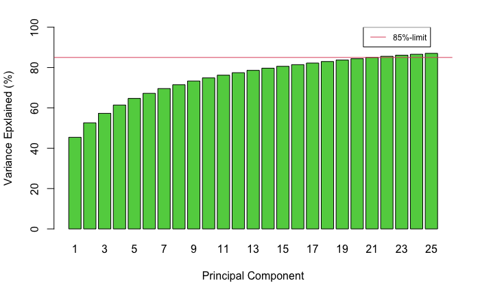

```r
legend(x=24, y=100, legend="85%-limit", col=2, lty=1, cex=.75)
```

```r
paste("PC's needed to explain 85% of the variance:", sum(var_exp <= 0.85) + 1)
```

[output not shown]

A new working data set was created by combining all observations of the digits 5 and 6.

```r
dat_5 = dat[which(dat[,1] == 5), 1:257]
dat_6 = dat[which(dat[,1] == 6), 1:257]
c_dat = rbind(dat_5, dat_6)
```

The data set was then divided into training set (80%) and testing set (20%) by random sampling.

```r
set.seed(1337)

# randomly split data into train and test, 80%/20%
n = dim(c_dat)[1]
idx = sample(1:n, floor(0.8 * n))
train_dat = c_dat[idx, ]
test_dat = c_dat[-idx, ]

train = train_dat[, 2:257]
train_label = train_dat[, 1]

test = test_dat[, 2:257]
test_label = test_dat[, 1]
```

A PCA, as presented in Section 1.2, was then performed on the training and testing set, respectively.

```r
# compute eigen vectors
X_train = matrix(unlist(train), nrow=dim(train)[1], ncol=256)
X_test = matrix(unlist(test), nrow=dim(test)[1], ncol=256)

# compute PC's for train and test data
S_train= t(X_train) %*% X_train
Q_train = eigen(S_train)$vectors
pc_train = X_train %*% Q_train
pc_test = X_test %*% Q_train
```

Consequently, a LDA classifier, as presented in Home Assignment 1, was fitted to the training data using only the first two principal components.

```r
# format training data
train_data = as.data.frame(cbind(pc_train, train_label))

# fit LDA model
mdl = lda(
    train_label ~ V1 + V2,
    data=train_data
)
```

```r
# predict test set
test_pred = predict(mdl, as.data.frame(pc_test))$class

# compute confusion matrix and test accuracy
test_res = confusionMatrix(
    data=factor(test_pred),
    reference=factor(test_label)
)
test_res$table
test_res$overall[1]
```

[output not shown]